# Why should we care about the study of plants?

## Without plants, most life would not exist!

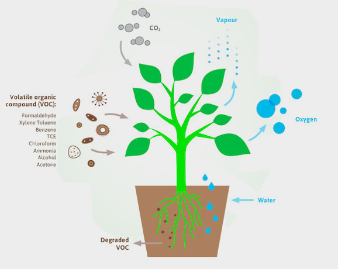

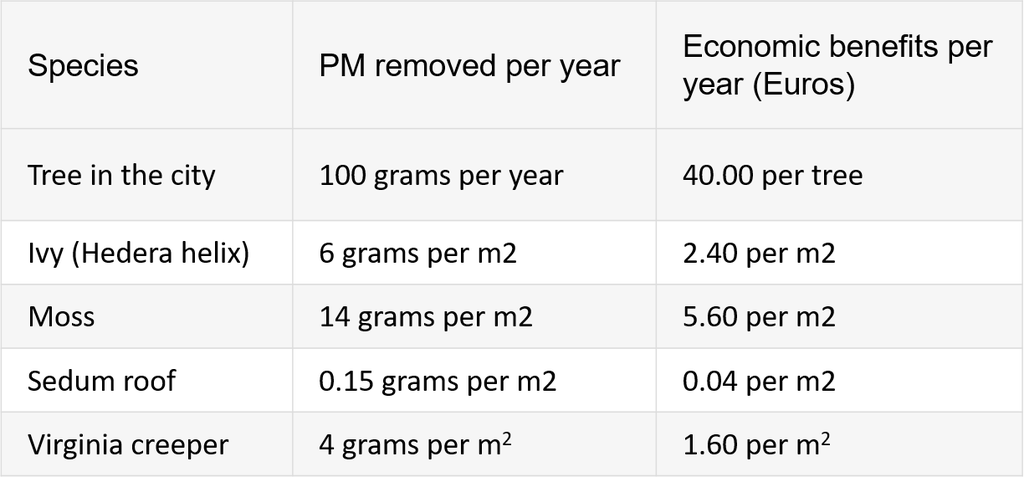

## Photosynthesis has provided O<sub>2</sub> for billions of years

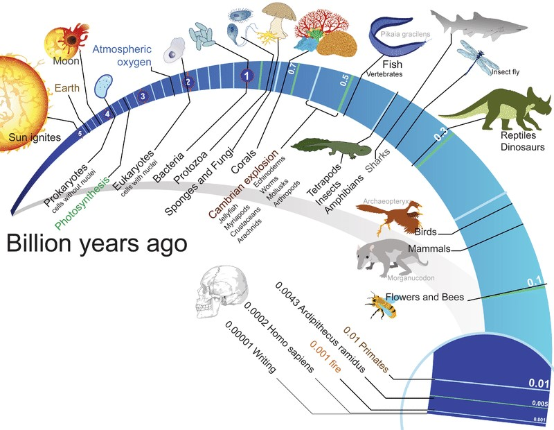

## Photosynthesis has provided O<sub>2</sub> for billions of years

- **↑ [O<sub>2</sub>] provided a new metabolic opportunity for biological diversification**
- **↑ [O<sub>2</sub>] promotes changes in chemical interactions between rocks, sand, clay, air, oceans, etc.**
- **Allows plants to be the base of every food chain**
  - starch storage in plants is major human food source

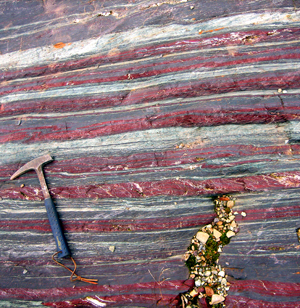

## Almost every living thing interacts with plants in some way

[figure not shown]

## Plants conditioned the land for animals

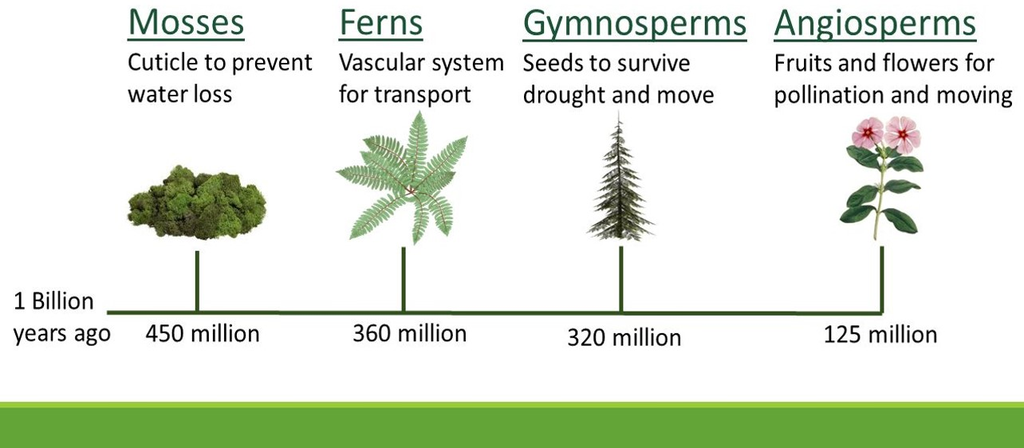

- **400 MYA: oldest know insects**
- **397 MYA: tetrapods evolve in shallow water**
- **340 MYA: amphibians evolve**
- **310 MYA: reptiles evolve**
- **Also… many mass extinctions**

## Plants are responsible for the products *WE* rely on

- **Vegetable and animal matter via agriculture and pasture lands allows us to live**
- **Textiles, lumber and medicine provide us quality of life**
- **Spices, perfumes, dyes, food stabilizers, emulsifiers, Starbucks, etc. allow us to live our best life**
- **Just based on this, can you imagine a life without plants??**
  - this semester we will try to live that life, for one day

[figure not shown]

## Plants may be responsible for the *future* products we rely on

**Photosynthetic organisms (plants, algae, marine phytoplankton) may be the future of energy and/or solutions to global change**

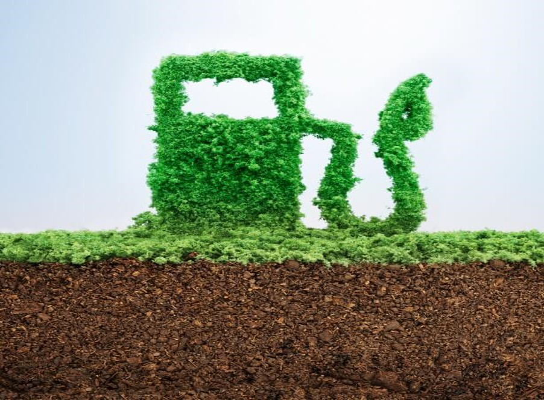

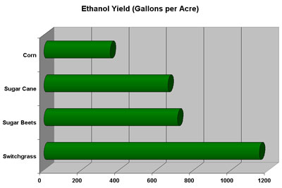

## In a time of uncertainty, plants still provide jobs

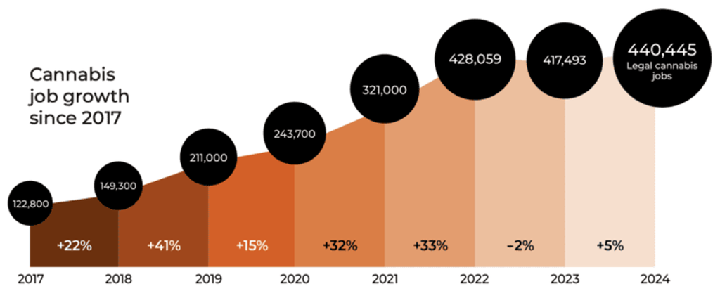

## Angiosperms are most important for humans

- **Flowering plants are most diverse and abundant group**
  - ~350,000 species
  - relatively new in terms of evolution
- **Most plant products utilized by society are angiosperms**
  - nearly all food staples
- **Irish potato famine nearly destroyed a society that was dependent on a single species of flowering plant**

[figure not shown]

## This semester, we will…..

- **Learn to identify plants in the wild**
  - and create plant collections
  - learn the value of plants in the wild
- **Understand how plants function**
  - identify how these processes affect humans
- **Explore the past, present and future of agriculture**
- **Dig into the various ways plants define our culture**

[figure not shown]

## Today….Why do people think plants are boring???

**Are plants considered boring because of how they are shown/portrayed to us in media, storytelling, education, etc.?**

**Or is it simply because they don’t move?**

**How do we ignore…BREAD, BEER, WINE, OXYGEN so easily?**

[figure not shown]